# 0. Instalações e imports

```python
import numpy as np
import pandas as pd
import seaborn as sns
import matplotlib.pyplot as plt
import sidrapy
import requests
from sklearn import preprocessing, svm
from sklearn.model_selection import train_test_split
from sklearn.linear_model import LinearRegression
from sklearn.metrics import mean_absolute_error, mean_squared_error
from re import search
from bs4 import BeautifulSoup
from datetime import date, timedelta
```

```python
def comp_interest(series: pd.Series, amount: float) -> float:
  '''Recebe uma pandas.Series com valores em porcentagem e um capital aplicado,
     e retorna o valor acumulado após o decorrer da série.'''
  return round(amount * (1 + series.mean()/100) ** len(series), 2)

def date_value(series: pd.Series, sel: list) -> dict:
    '''Recebe uma pandas.Series e uma seleção que deve retornar apenas 1 item da mesma,
       e retorna a combinação do índice (data) convertido em texto e valor do item
       arredondado num dicionário com duas chaves.'''
    if sel.sum() != 1: raise Exception("'sel' must return only one True")
    date = series[sel].index.strftime('%m/%Y').astype(str)
    value = round(series[sel], 2)
    out = dict()
    for (date, value) in zip(date, value): out['idx'] = date; out['val'] = value
    return out

class lm:

    def __init__(self, data, y_var):
        # data prep
        self.data = data.dropna()
        self.y = self.data[[y_var]].to_numpy()
        self.x = self.data.loc[:, self.data.columns != y_var].to_numpy()

        # split data
        self.x_train, self.x_test, self.y_train, self.y_test = train_test_split(
            self.x, self.y, test_size = 0.25)

        # model evalution
        self.lm = LinearRegression().fit(self.x, self.y)
        self.lm_train = LinearRegression().fit(self.x_train, self.y_train)

        # metrics
        self.y_pred = self.lm.predict(self.x)
        self.y_pred_train = self.lm_train.predict(self.x_test)

        self.residuals = self.y_pred - self.y
        #self.residuals_train = self.y_pred_train - self.y_train

        self.coef = dict(
            coefficients=self.lm.coef_.tolist(),
            intercept=self.lm.intercept_.tolist())
        self.coef_train = dict(
            coefficients=self.lm_train.coef_.tolist(),
            intercept=self.lm_train.intercept_.tolist())

        self.r_sqr = self.lm.score(self.x, self.y)
        self.r_sqr_train = self.lm_train.score(self.x_test, self.y_test)

        self.mae = mean_absolute_error(y_true=self.y, y_pred=self.y_pred)
        self.mae_train = mean_absolute_error(
            y_true=self.y_test, y_pred=self.y_pred_train)

        self.mse = mean_squared_error(y_true=self.y, y_pred=self.y_pred)
        self.mse_train = mean_squared_error(
            y_true=self.y_test, y_pred=self.y_pred_train)

        self.rmse = mean_squared_error(
            y_true=self.y, y_pred=self.y_pred, squared=False)
        self.rmse_train = mean_squared_error(
            y_true=self.y_test, y_pred=self.y_pred_train, squared=False)

    def params(self, train=True, deep=True):
        if train: return self.lm_train.get_params(deep=deep)
        else: self.lm.get_params(deep=deep)

    def predict(self, x, train=True):
        x = pd.DataFrame(x).to_numpy()
        if train: out = self.lm_train.predict(x)
        else: out = self.lm.predict(x)
        return pd.DataFrame({'pred': out[:,0]})
```

# 1. Coletando dados dos últimos 5 anos

Utilizando a variação mensal da inflação IPCA, obtido através da API do Sidra (IBGE); e a taxa CDI obtido no site debit.com.br usando técnicas de *webscraping*. Fazendo um recorte de datas para os últimos 5 anos.

```python
# Obtendo as datas a ser usadas
today = pd.to_datetime('today').normalize()

dates = pd.date_range(start=today-pd.offsets.MonthBegin(61), end=today, periods=61)
dates_code = pd.Series(dates).dt.strftime('%Y%m')
```

## 1.1. Variação mensal IPCA

```python
# obtendo variação mensal dos preços IPCA no Brasil
inflac = sidrapy.get_table(
    table_code='1737',
    variable='63',
    period=','.join(list(dates_code)),
    territorial_level='1',
    ibge_territorial_code='1')
```

## 1.2. Rendimento do CDI no mês

```python
# obtendo dados do CDI ao mês no Brasil
webpage = requests.get('https://www.debit.com.br/tabelas/cdi')
soup = BeautifulSoup(webpage.text, 'html.parser')

juros_tabelas = soup.find_all("tbody")
linhas = []

for tabela in juros_tabelas:
    nova_linha = [i.get_text() for i in tabela.find_all("td")]
    linhas.append(nova_linha)

juros = pd.DataFrame(linhas, columns=['mes', 'juros'])
juros['mes'] = pd.to_datetime(juros['mes'], format='%m/%Y')
juros['juros'] = juros['juros'].str.replace(',', '.').astype(float)
juros.set_index('mes', inplace=True)
```

## 1.3. Tratamento dos dados

⚠ Não executar as células abaixo mais de uma vez após executar as células de cima

```python
# Tratamento inicial dos dados de inflação
new_names = {'V':'inflac', 'D2C':'mes'}
inflac = inflac[['V', 'D2C']].tail(-1).rename(new_names, axis=1)

inflac['mes'] = pd.to_datetime(inflac['mes'], format='%Y%m')
inflac = inflac.set_index('mes')
inflac.index.name = None

inflac['inflac'] = inflac['inflac'].str.replace(',', '.').astype(float)
```

```python
# Unir dabelas e selecionar datas de interesse
df = inflac.join(juros)
```

# 2. Taxa de Juros Real

## 2.1. IPCA versus CDI

Agora fazendo algumas visualizações, fica fácil de perceber que as variações da inflação parecem mais erráticas e imprevisíveis, enquanto que a taxa de juros parece seguir um curso.

A explicação para o isto é que a taxa de juros CDI sempre acompanha a SELIC definida pelo [Conselho Monetário Nacional](https://www.gov.br/fazenda/pt-br/assuntos/cmn), por se tratar de uma taxa definida artificialmente, fica fácil prevê-la. Já a inflação IPCA é definida dinâmicamente pelo mercado, e é apenas medida pelo IBGE, que não tem poder de influência algum sobre ela.

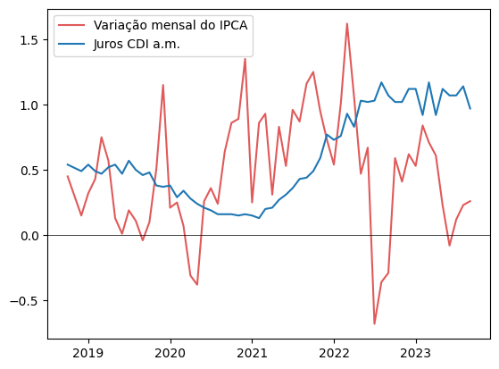

```python
# CDI versus Inflação IPCA
plt.plot(df.index, df.inflac, label='Variação mensal do IPCA', color='#e05a5a')
plt.plot(df.index, df.juros, label='Juros CDI a.m.')
plt.axhline(y = 0, color = 'black', linewidth=.5)
plt.legend()
plt.show()
```

## 2.2. Encontrando os juros reais

Adicionando juros real, usando a fórmula de Fisher:

$r=\frac{(1+i)}{(1+\pi)}-1$

Onde $i$ são os juros nominais, $\pi$ a inflação, e $r$ os juros reais.

```python
df['juros_real'] = ((1+df.juros)/(1+df.inflac)) -1
```

Agora que temos os juros reais calculados, podemos observar sua flutuação mensal ao longo dos últimos 5 anos:

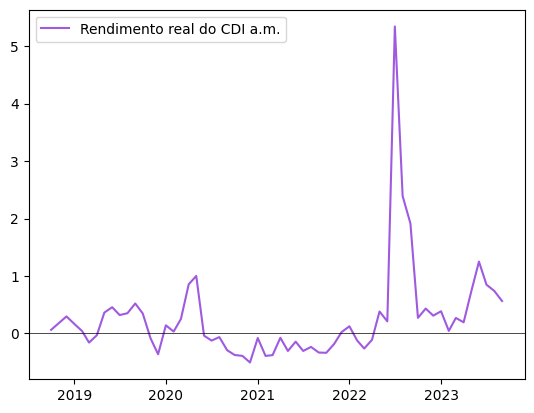

```python
# Rendimento real do CDI a.m.
plt.plot(
    df.index, df.juros_real,
    label='Rendimento real do CDI a.m.', color='#9f5ae0')
plt.axhline(y = 0, color = 'black', linewidth=.5)
plt.legend()
plt.show()
```

Algumas estatísticas interessantes sobre o rendimento real do CDI no período

```python
max_rent = date_value(df.juros_real, df.juros_real==df.juros_real.max())
min_rent = date_value(df.juros_real, df.juros_real==df.juros_real.min())
print(
    f'Número de meses positivo: {df.juros_real.gt(0).sum()}',
    f'Número de meses negativo: {df.juros_real.lt(0).sum()}',
    f'\nAplicando mil reais no CDI a 5 anos atrás, você teria acumulado:',
    f'R$ {comp_interest(df.juros_real, 1000)} rendimento à preços da data da aplicação',
    f'R$ {comp_interest(df.juros, 1000)} rendimento à preços correntes',
    f'\nA maior rentabiliade real observada foi no mês {max_rent["idx"]} ({max_rent["val"]}%)',
    f'A menor rentabiliade real observada foi no mês {min_rent["idx"]} ({min_rent["val"]}%)',
    f'\nRentabilidade a.m. real média no período: {round(df.juros_real.mean(), 4)}%',
    f'Rentabilidade a.m. nominal média no período: {round(df.juros.mean(), 4)}%',
    f'Variação média dos preços IPCA ao mês: {round(df.inflac.mean(), 4)}%',
    f'\nRentabilidade a.a. real média no período: {round(((1 + df.juros_real.mean()/100)**12 -1)*100, 4)}%',
    f'Rentabilidade a.a. nominal média no período: {round(((1 + df.juros.mean()/100)**12 -1)*100, 4)}%',
    f'Variação média dos preços IPCA ao ano: {round(((1 + df.inflac.mean()/100)**12 -1)*100, 4)}%',
    sep='\n'
)
```

```
Número de meses positivo: 35
Número de meses negativo: 25

Aplicando mil reais no CDI a 5 anos atrás, você teria acumulado:
R$ 1172.88 rendimento à preços da data da aplicação
R$ 1426.96 rendimento à preços correntes

A maior rentabiliade real observada foi no mês 07/2022 (5.34%)
A menor rentabiliade real observada foi no mês 12/2020 (-0.51%)

Rentabilidade a.m. real média no período: 0.2661%
Rentabilidade a.m. nominal média no período: 0.5943%
Variação média dos preços IPCA ao mês: 0.4743%

Rentabilidade a.a. real média no período: 3.2407%
Rentabilidade a.a. nominal média no período: 7.3698%
Variação média dos preços IPCA ao ano: 5.8429%
```

## 2.3. Impacto da inflação no rendimento acumulado do CDI

```python
df['inflac_acm'] = df.inflac.cumsum()
df['juros_acm'] = df.juros.cumsum()
df['juros_real_acm'] = df.juros_real.cumsum()
```

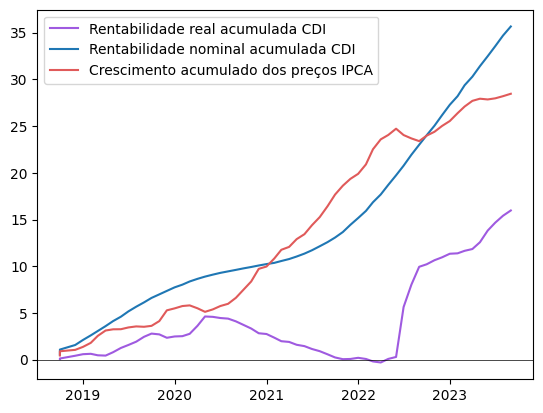

```python
plt.plot(df.index, df.juros_real_acm, label='Rentabilidade real acumulada CDI', color='#9f5ae0')
plt.plot(df.index, df.juros_acm, label='Rentabilidade nominal acumulada CDI')
plt.plot(df.index, df.inflac_acm, label='Crescimento acumulado dos preços IPCA', color='#e05a5a')
plt.axhline(y=0, color='black', linewidth=.5)
plt.legend()
plt.show()
```

# 3. Relação entre juros e inflação

Seria interessante se a taxa de juros atual tivesse alguma relação com a inflação no futuro, ou vice-versa. Já que estamos com os dados aqui, podemos tentar tirar a prova desta tese.

```python
df.corr()[['juros', 'juros_acm']]\
    .style.background_gradient(cmap='RdBu_r')
```

|  | juros | juros_acm |
| --- | --- | --- |
| inflac | -0.148010 | -0.038268 |
| juros | 1.000000 | 0.782839 |
| juros_real | 0.481180 | 0.327762 |
| inflac_acm | 0.802104 | 0.944385 |
| juros_acm | 0.782839 | 1.000000 |
| juros_real_acm | 0.604175 | 0.849250 |

Considerando as correlações mais relevantes entre juros e inflação. As duas maiores correlações que conseguimos encontrar foram:

1. Inflação acumulada - Juros acumulados
2. Inflação acumulada - Juros do mês

Os outros casos não são tão surpreendentes porque relacionam uma variável com outra que usamos para obtê-la (usamos inflação para obter os juros reais).

Vamos dar uma olhada em como nossa melhor correlação se parece:

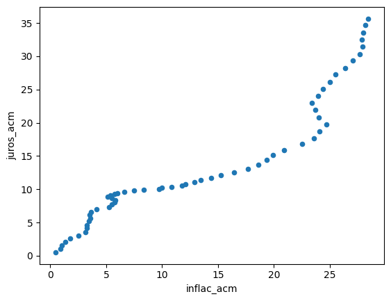

```python
df.plot(kind='scatter', x='inflac_acm', y='juros_acm');
```

Muito interessante como estas duas variáveis parecem estar relacionadas! Mas existem algumas coisas que explicam este fato:

Uma delas é a forma com estas séries foram construídas. Você deve lembrar que no tópico 2.3 eu usei a função `cumsum()` para construir ambas as funções. Uma maneira de entender o que esta função faz, é que ela "emplilha" o próximo valor em cima da pilha de todos os outros valores anteriores, então pelo simples fato de a maioria dos valores das séries originais serem positivos (como vimos em 2.1), temos uma linha crescente como resultado em ambos os casos.

Mas outra coisa que podemos usar como explicação também é a função da taxa base de juros. Como eu disse anteriormente, o CDI sempre acompanha a SELIC, e o Conselho Monetário usa essa taxa para controlar a inflação, consequentemente, ele deve reagir ao nível atual de inflação definindo uma nova taxa de juros (juros altos em tempos de inflação alta). Como resultado, temos uma curva de juros real modesta, mas na maior parte do tempo positiva (como vimos em 2.2).

## 3.1. Tempo de resposta da inflação

Agora que sabemos como a inflação e a taxa de juros estão relacionadas entre si, uma coisa interessante que podemos fazer é tentar medir quanto tempo deve passar até que a inflação comece a responder à mudança da taxa de juros.

A maneira simples de fazer isso é atrasar uma série em relação à outra até que uma delas até conseguir a maior correlação possível. O tempo de atraso aplicado será o tempo de reação esperado para uma mudança na taxa de juros.

```python
# Testando até 2 anos de defasagem, mês a mês
pd.options.mode.chained_assignment = None
bootstraps = df[['juros_acm', 'inflac_acm']]
for i in range(1, 25):
    bootstraps.loc[:,f'juros_acm_lag{i}'] = bootstraps.loc[:,'juros_acm'].shift(-i)
```

```python
# Obtendo a defasagem que mostra a maior correlação com inflac_acm
lag_var = bootstraps.corr().loc['inflac_acm', bootstraps.columns != 'inflac_acm'].idxmax()

# Número de meses
lag_amount = search(r'\d+', lag_var)[0]
```

Abaixo podemos ver qual a melhor defasagem para se adotar, e como a **evolução dos preços** se parece com a **evolução dos rendimentos acumulados da taxa de juros defasada** quando estão lado a lado.

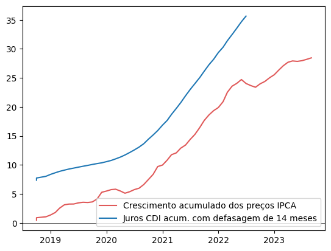

```python
plt.plot(df.index, df.inflac_acm, label='Crescimento acumulado dos preços IPCA', color='#e05a5a')
plt.plot(df.index, bootstraps[lag_var], label=f'Juros CDI acum. com defasagem de {lag_amount} meses')
plt.axhline(y=0, color='black', linewidth=.5)
plt.legend()
plt.show()
```

## 3.2. Prevendo a inflação futura com os juros presentes

Agora que já temos uma boa idéia de quanto tempo será necessário para que a inflação reaja à taxa de juros, podemos tentar prever a inflação nos próximos meses!

Você já deve estar cansado desse texto, mas o que temos no final vai compensar a leitura. Já que a taxa de juros de meses atrás pode ajudar a entender a inflação de hoje, podemos usar a taxa de juros de hoje para tentar entender a inflação do futuro! Vamos começar treinando um modelo de regressão, o nosso modelo terá este formato:

$$ \pi_{(t=14)} = \alpha \times i_{t=0} + \beta $$

Significa que usaremos os estimadores taxa de juros $i$ no momento $t=0$ para prever a inflação $\pi$ no momento $t=14$. $\alpha$ e $\beta$ vão nos ajudar a ajustar a curva de regressão no lugar certo, estes são os nossos parâmetros.

O motivo de usar a inflação adiantada, é ter a oportunidade de treinar o modelo com os dados mais recentes de inflação, o que é muito importante quando se trata de realizar previsões para o futuro (forecasting).

```python
# modelo linear, usando inflação adiantada em vez de juros atrasados
df['inflac_acm_adv'] = df.inflac_acm.shift(int(lag_amount))
mdl_df = df[['inflac_acm_adv', 'juros_acm']]\
    .dropna()
model = lm(mdl_df, y_var='inflac_acm_adv')
```

Agora sabemos o parâmetro de inclinação $\alpha$ , e o intercepto $\beta$.

```python
model.coef
```

```
{'coefficients': [[0.8502592099620693]], 'intercept': [-4.7329619997974905]}
```

Podemos ver o ajuste do modelo aos dados.

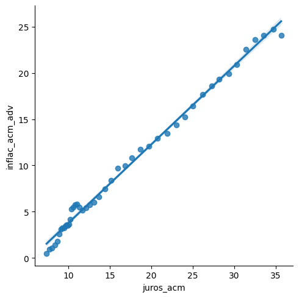

```python
sns.lmplot(x='juros_acm', y='inflac_acm_adv', data=df, order=1)
plt.show()
```

E podemos também fazer previsões para a inflação usando esse modelo:

```python
# datas do vetor de previsões
pred_idx = mdl_df.index + pd.offsets.MonthBegin(int(lag_amount))
# vetor de previsões sem datas
alpha = model.coef['coefficients'][0][0]
beta = model.coef['intercept'][0]
last_obs = mdl_df['juros_acm'].iloc[-int(lag_amount)]

pred = model.predict(mdl_df[['inflac_acm_adv']], train=False) + last_obs
# vetor de previsões com datas
pred.index = pred_idx
# selecionando apenas previsões do futuro
pred = pred.tail(int(lag_amount))
# adicionando intervalo de confiança de 95%
ic_band = np.std(model.residuals[:,0])*1.96
pred['pos_ic'] = pred['pred'] + ic_band
pred['neg_ic'] = pred['pred'] - ic_band
```

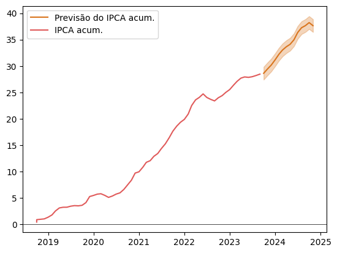

```python
plt.plot(pred.index, pred['pred'], label=f'Previsão do IPCA acum.', color='#d9751e')
plt.plot(df.index, df['inflac_acm'], label='IPCA acum.', color='#e05a5a')
plt.fill_between(x=pred.index, y1=pred['neg_ic'], y2=pred['pos_ic'], alpha=.3, color='#d9751e')
plt.axhline(y=0, color='black', linewidth=.5)
plt.legend()
plt.show()
```

```python
# exportando dados gerados
df.to_csv('df.csv')
mdl_df.to_csv('mdl_df.csv')
pred.to_csv('pred.csv')
```

```python
%%capture
!!jupyter nbconvert --to html taxa_de_juros_real.ipynb
```

```
['[NbConvertApp] Converting notebook taxa_de_juros_real.ipynb to html',
 '[NbConvertApp] WARNING | Alternative text is missing on 7 image(s).',
 '[NbConvertApp] Writing 629155 bytes to taxa_de_juros_real.html']
```